# examples_1201

Solve the equation below.
$$12=\frac{x}{2}+9$$

We know that 12 equals the result when we start with $x$ and then divide by 2 and then add 9. In order to undo those operations, apply the inverse operations in reverse order: subtract 9 and then multiply by 2.

$$x = (12-9)\cdot 2$$

So,

$$x=6$$

Solve the equation below.
$$54=(x+2)\cdot
6$$

We know that 54 equals the result when we start with $x$ and then add 2 and then multiply by 6. In order to undo those operations, apply the inverse operations in reverse order: divide by 6 and then subtract 2.

$$x = \frac{54}{6}-2$$

So,

$$x=7$$

Solve the equation below.
$$36=(x-4)\cdot
9$$

We know that 36 equals the result when we start with $x$ and then subtract 4 and then multiply by 9. In order to undo those operations, apply the inverse operations in reverse order: divide by 9 and then add 4.

$$x = \frac{36}{9}+4$$

So,

$$x=8$$

Solve the equation below.
$$7=\frac{x+8}{2}$$

We know that 7 equals the result when we start with $x$ and then add 8 and then divide by 2. In order to undo those operations, apply the inverse operations in reverse order: multiply by 2 and then subtract 8.

$$x = 2\cdot 7-8$$

So,

$$x=6$$

Solve the equation below.
$$19=3
x+7$$

We know that 19 equals the result when we start with $x$ and then multiply by 3 and then add 7. In order to undo those operations, apply the inverse operations in reverse order: subtract 7 and then divide by 3.

$$x = \frac{19-7}{3}$$

So,

$$x=4$$

Solve the equation below.
$$2=\frac{x}{2}-3$$

We know that 2 equals the result when we start with $x$ and then divide by 2 and then subtract 3. In order to undo those operations, apply the inverse operations in reverse order: add 3 and then multiply by 2.

$$x = (2+3)\cdot 2$$

So,

$$x=10$$

Solve the equation below.
$$8=\frac{x}{2}+3$$

We know that 8 equals the result when we start with $x$ and then divide by 2 and then add 3. In order to undo those operations, apply the inverse operations in reverse order: subtract 3 and then multiply by 2.

$$x = (8-3)\cdot 2$$

So,

$$x=10$$

Solve the equation below.
$$2=\frac{x-4}{3}$$

We know that 2 equals the result when we start with $x$ and then subtract 4 and then divide by 3. In order to undo those operations, apply the inverse operations in reverse order: multiply by 3 and then add 4.

$$x = 3\cdot 2+4$$

So,

$$x=10$$

Consider the shifted squaring function graphed below:

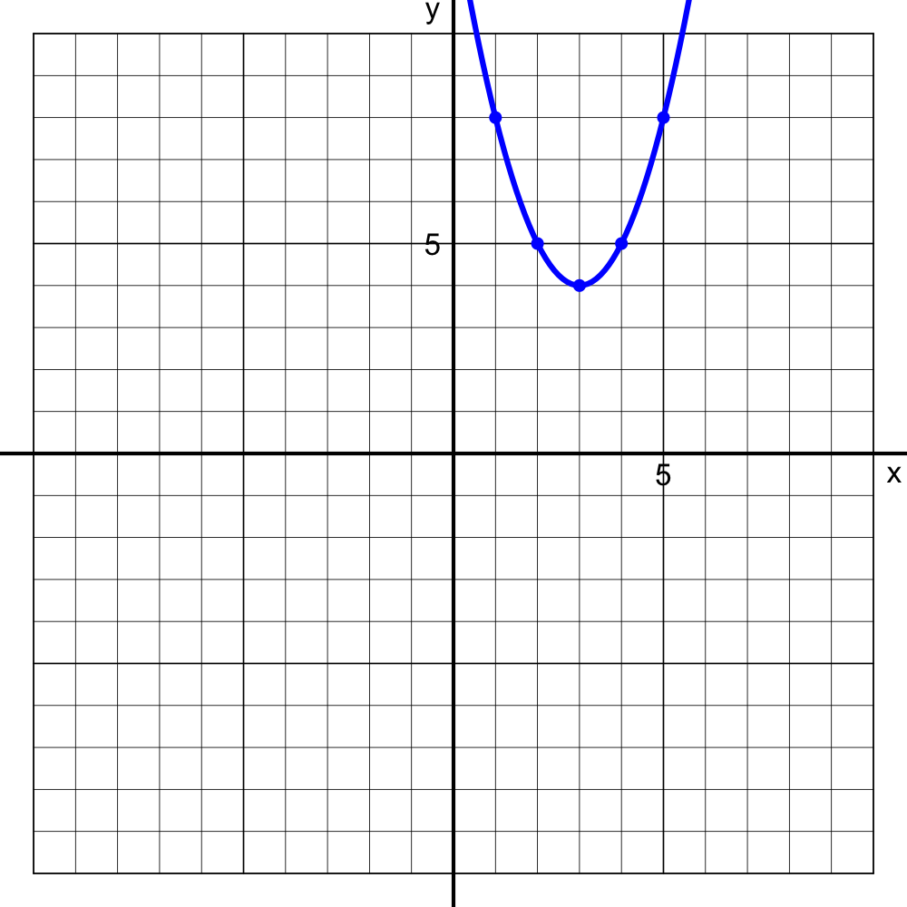

Which equation represents the plotted curve?

$y=(x-3)^2-4$$y=(x-3)^2+4$$y=(x-4)^2-3$$y=(x-4)^2+3$$y=(x+3)^2-4$$y=(x+3)^2+4$$y=(x+4)^2-3$$y=(x+4)^2+3$

The correct option is:

$$y=(x-3)^2+4$$

Notice, the parent function $y=x^2$ has a vertex at $(0,0)$. The shifts are 3 units right and 4 units up. When $x=3$, the argument of the function is 0. This line of reasoning explains why the horizontal shift is "backwards".

Also, the formal word for "shift" is "translate".

Consider the shifted squaring function graphed below:

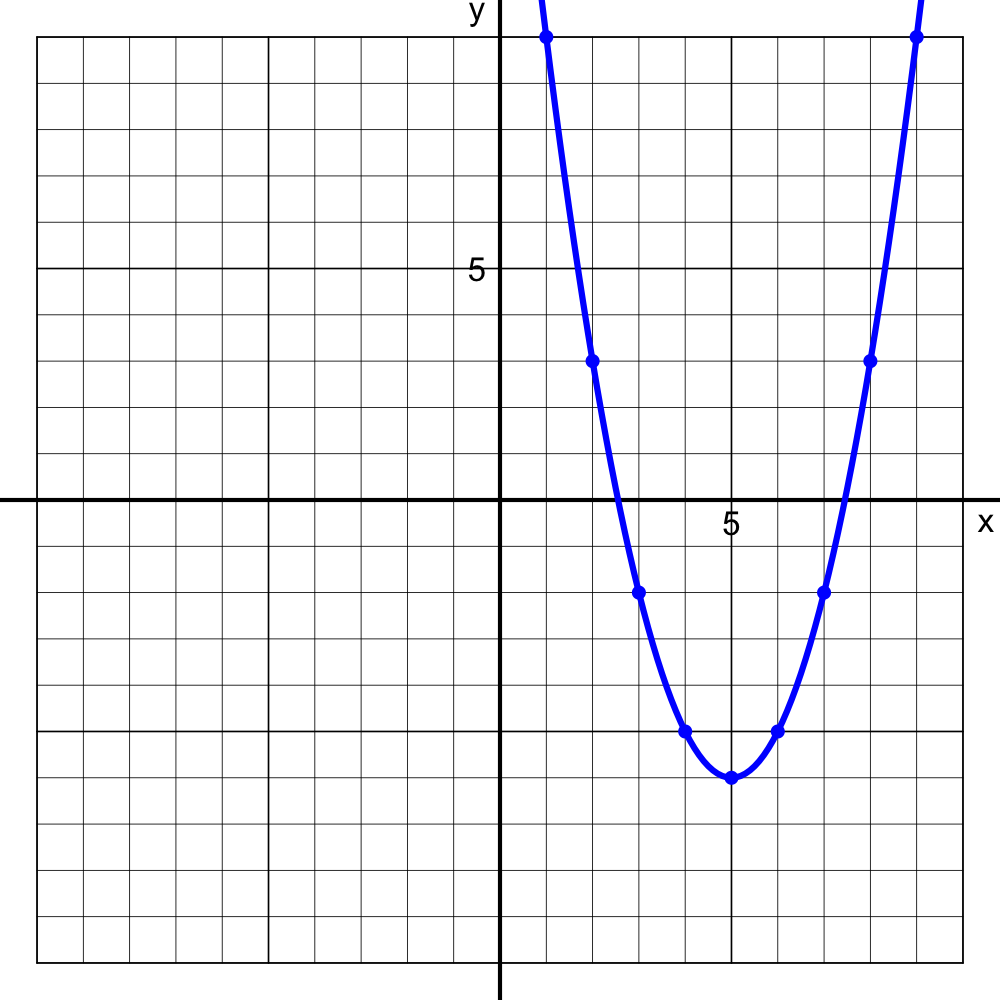

Which equation represents the plotted curve?

$y=(x-5)^2-6$$y=(x-5)^2+6$$y=(x-6)^2-5$$y=(x-6)^2+5$$y=(x+5)^2-6$$y=(x+5)^2+6$$y=(x+6)^2-5$$y=(x+6)^2+5$

The correct option is:

$$y=(x-5)^2-6$$

Notice, the parent function $y=x^2$ has a vertex at $(0,0)$. The shifts are 5 units right and 6 units down. When $x=5$, the argument of the function is 0. This line of reasoning explains why the horizontal shift is "backwards".

Also, the formal word for "shift" is "translate".

Consider the shifted squaring function graphed below:

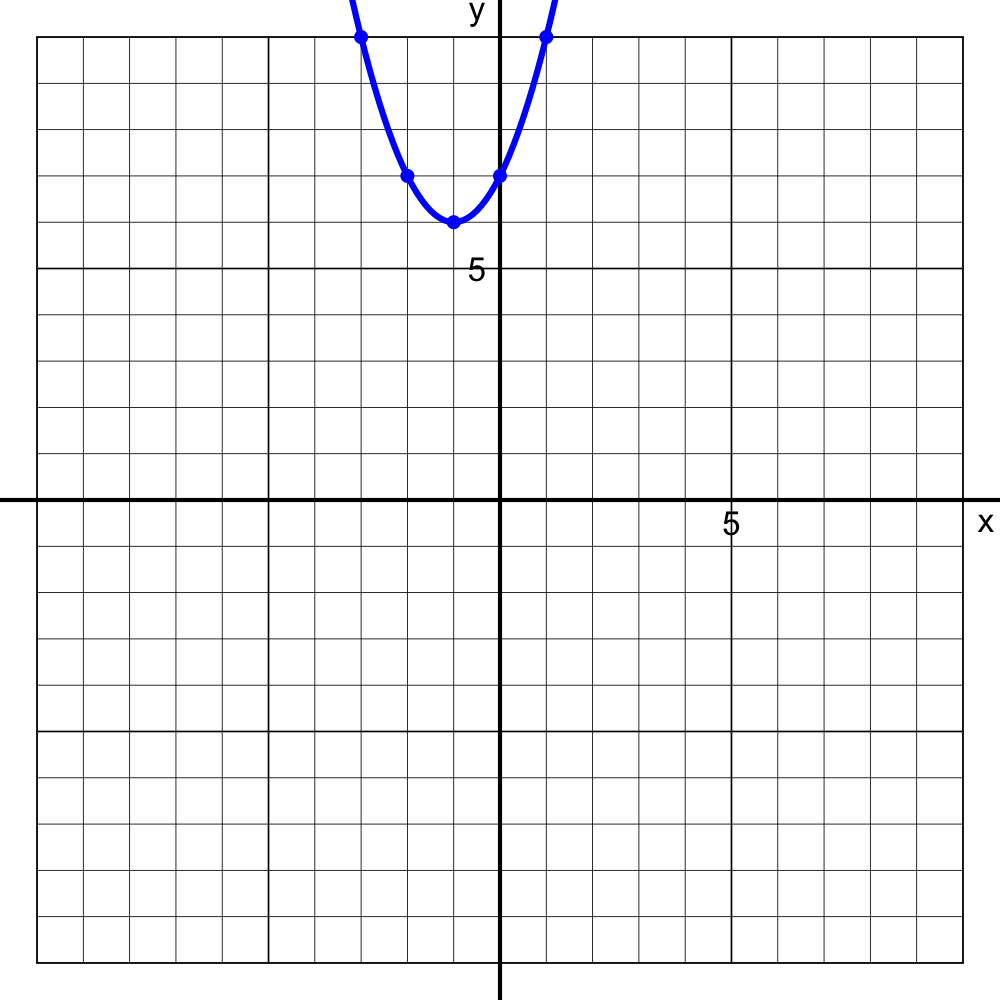

Which equation represents the plotted curve?

$y=(x-1)^2-6$$y=(x-1)^2+6$$y=(x-6)^2-1$$y=(x-6)^2+1$$y=(x+1)^2-6$$y=(x+1)^2+6$$y=(x+6)^2-1$$y=(x+6)^2+1$

The correct option is:

$$y=(x+1)^2+6$$

Notice, the parent function $y=x^2$ has a vertex at $(0,0)$. The shifts are 1 units left and 6 units up. When $x=-1$, the argument of the function is 0. This line of reasoning explains why the horizontal shift is "backwards".

Also, the formal word for "shift" is "translate".

Consider the shifted squaring function graphed below:

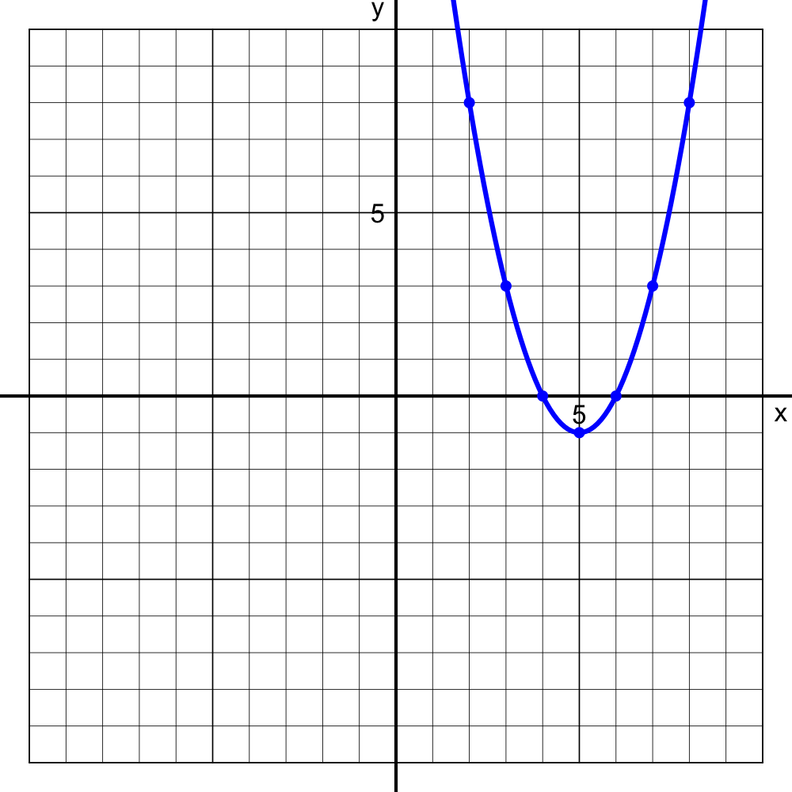

Which equation represents the plotted curve?

$y=(x-1)^2-5$$y=(x-1)^2+5$$y=(x-5)^2-1$$y=(x-5)^2+1$$y=(x+1)^2-5$$y=(x+1)^2+5$$y=(x+5)^2-1$$y=(x+5)^2+1$

The correct option is:

$$y=(x-5)^2-1$$

Notice, the parent function $y=x^2$ has a vertex at $(0,0)$. The shifts are 5 units right and 1 units down. When $x=5$, the argument of the function is 0. This line of reasoning explains why the horizontal shift is "backwards".

Also, the formal word for "shift" is "translate".

Consider the shifted squaring function graphed below:

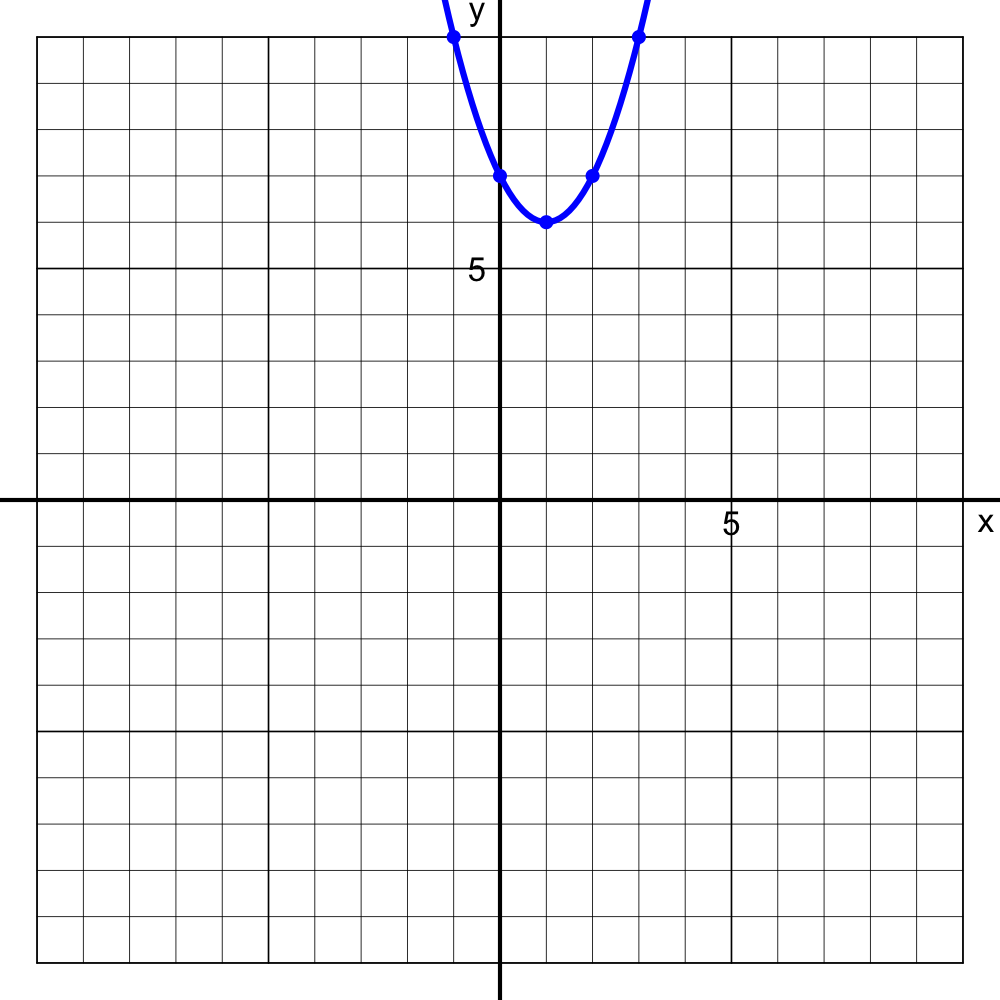

Which equation represents the plotted curve?

$y=(x-1)^2-6$$y=(x-1)^2+6$$y=(x-6)^2-1$$y=(x-6)^2+1$$y=(x+1)^2-6$$y=(x+1)^2+6$$y=(x+6)^2-1$$y=(x+6)^2+1$

The correct option is:

$$y=(x-1)^2+6$$

Notice, the parent function $y=x^2$ has a vertex at $(0,0)$. The shifts are 1 units right and 6 units up. When $x=1$, the argument of the function is 0. This line of reasoning explains why the horizontal shift is "backwards".

Also, the formal word for "shift" is "translate".

Consider the shifted squaring function graphed below:

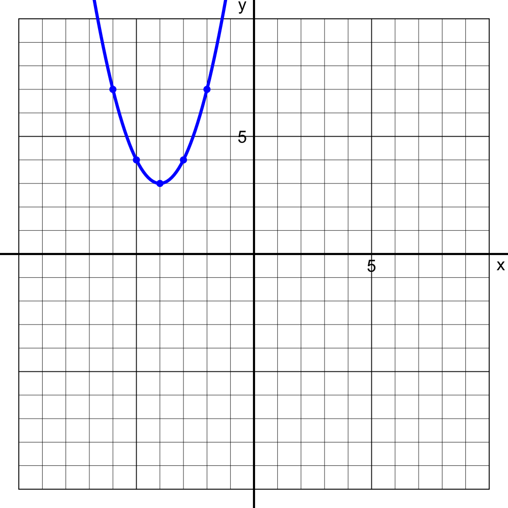

Which equation represents the plotted curve?

$y=(x-3)^2-4$$y=(x-3)^2+4$$y=(x-4)^2-3$$y=(x-4)^2+3$$y=(x+3)^2-4$$y=(x+3)^2+4$$y=(x+4)^2-3$$y=(x+4)^2+3$

The correct option is:

$$y=(x+4)^2+3$$

Notice, the parent function $y=x^2$ has a vertex at $(0,0)$. The shifts are 4 units left and 3 units up. When $x=-4$, the argument of the function is 0. This line of reasoning explains why the horizontal shift is "backwards".

Also, the formal word for "shift" is "translate".

Consider the shifted squaring function graphed below:

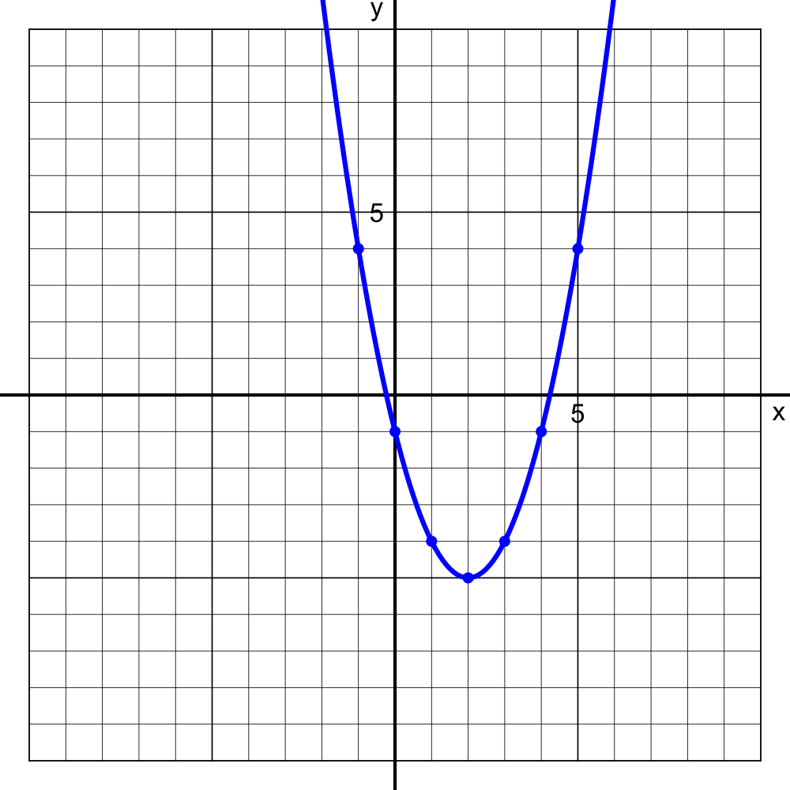

Which equation represents the plotted curve?

$y=(x-2)^2-5$$y=(x-2)^2+5$$y=(x-5)^2-2$$y=(x-5)^2+2$$y=(x+2)^2-5$$y=(x+2)^2+5$$y=(x+5)^2-2$$y=(x+5)^2+2$

The correct option is:

$$y=(x-2)^2-5$$

Notice, the parent function $y=x^2$ has a vertex at $(0,0)$. The shifts are 2 units right and 5 units down. When $x=2$, the argument of the function is 0. This line of reasoning explains why the horizontal shift is "backwards".

Also, the formal word for "shift" is "translate".

Consider the shifted squaring function graphed below:

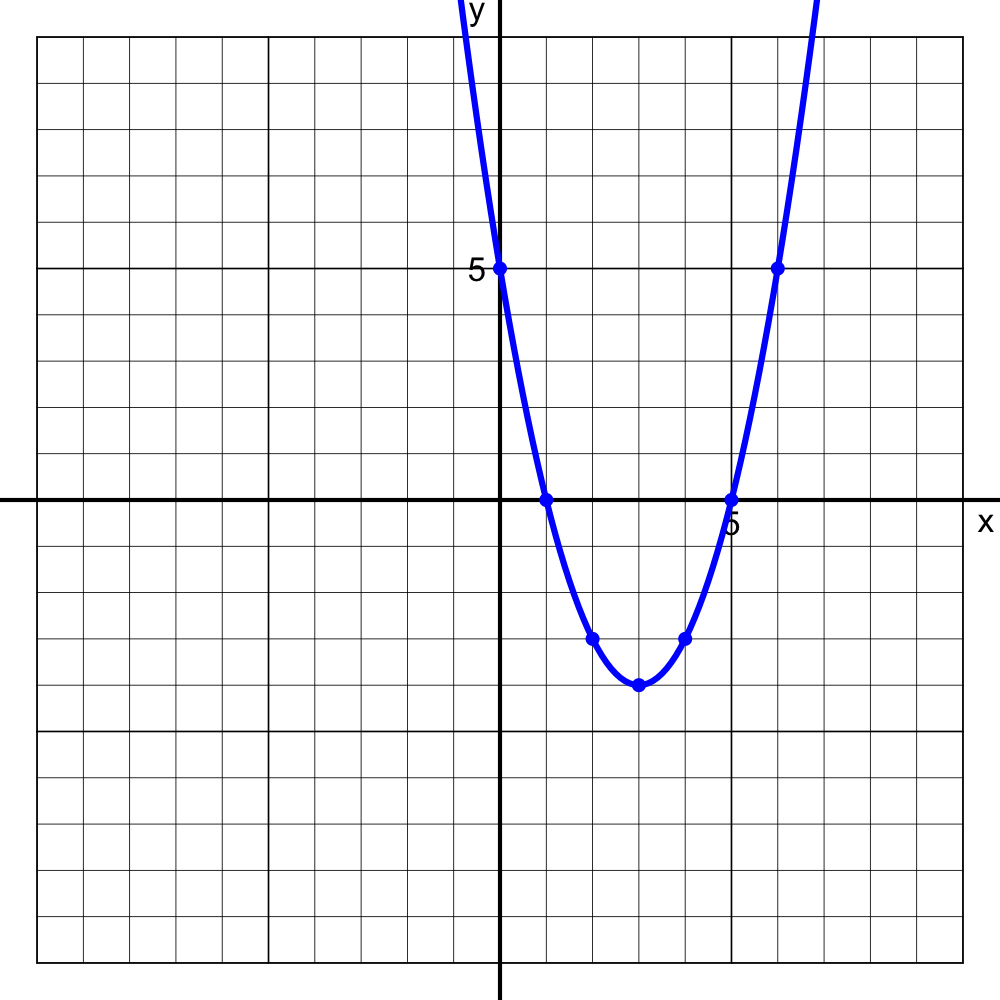

Which equation represents the plotted curve?

$y=(x-3)^2-4$$y=(x-3)^2+4$$y=(x-4)^2-3$$y=(x-4)^2+3$$y=(x+3)^2-4$$y=(x+3)^2+4$$y=(x+4)^2-3$$y=(x+4)^2+3$

The correct option is:

$$y=(x-3)^2-4$$

Notice, the parent function $y=x^2$ has a vertex at $(0,0)$. The shifts are 3 units right and 4 units down. When $x=3$, the argument of the function is 0. This line of reasoning explains why the horizontal shift is "backwards".

Also, the formal word for "shift" is "translate".

Consider the quadratic function graphed below:

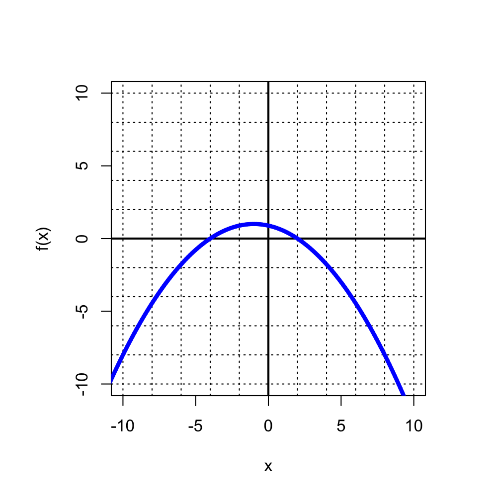

- What is the interval(s) over which the function is positive?
- What is the interval(s) over which the function is negative?
- What is the interval(s) over which the function is increasing?
- What is the interval(s) over which the function is decreasing?
- What is the domain (in interval notation)?
- What is the range (in interval notation)?
- Positive: (-4,2)
- Negative: (-∞,-4)U(2,∞)
- Increasing: (-∞,-1)
- Decreasing: (-1,∞)
- Domain: (-∞,∞)
- Range: (-∞,1]
- The function "is positive" when $f(x)>0$. The interval refers to the $x$ values (inputs) that produce a positive output. Determine where the curve is above the $x$ axis. Indicate "where" with the $x$ values at the endpoints: (-4,2)
- The function "is negative" when $f(x)<0$. The interval refers to the $x$ values (inputs) that produce a negative output. Determine where the curve is below the $x$ axis. Indicate "where" with the $x$ values at the endpoints: (-∞,-4)U(2,∞)
- The function is increasing when an ant going left-to-right is walking up hill: (-∞,-1)
- The function is decreasing when an ant going left-to-right is walking down hill: (-1,∞)

Consider the quadratic function graphed below:

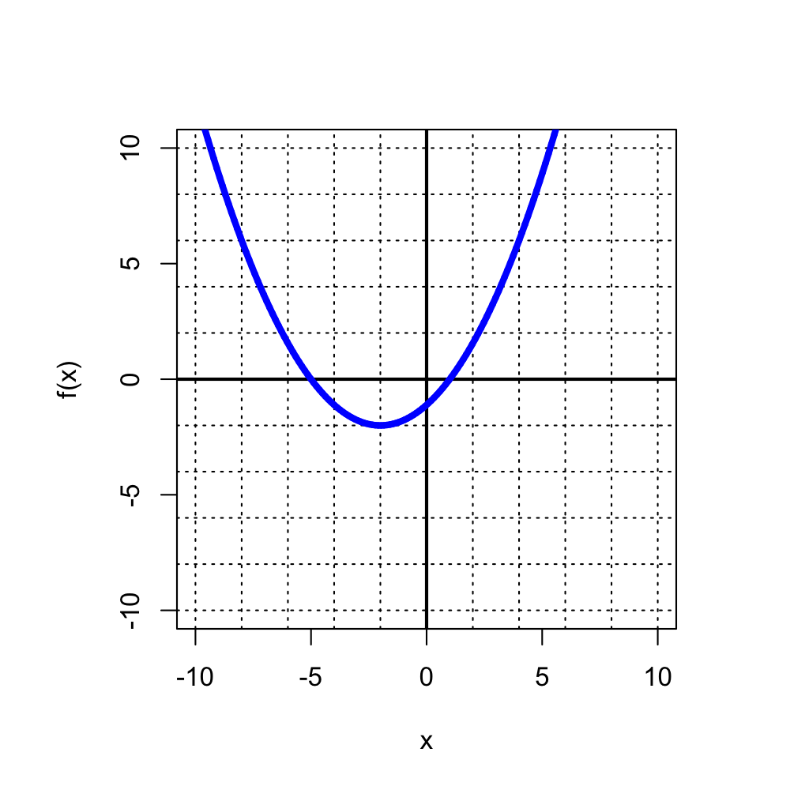

- What is the interval(s) over which the function is positive?
- What is the interval(s) over which the function is negative?
- What is the interval(s) over which the function is increasing?
- What is the interval(s) over which the function is decreasing?
- What is the domain (in interval notation)?
- What is the range (in interval notation)?
- Positive: (-∞,-5)U(1,∞)
- Negative: (-5,1)
- Increasing: (-2,∞)
- Decreasing: (-∞,-2)
- Domain: (-∞,∞)
- Range: [-2,∞)
- The function "is positive" when $f(x)>0$. The interval refers to the $x$ values (inputs) that produce a positive output. Determine where the curve is above the $x$ axis. Indicate "where" with the $x$ values at the endpoints: (-∞,-5)U(1,∞)
- The function "is negative" when $f(x)<0$. The interval refers to the $x$ values (inputs) that produce a negative output. Determine where the curve is below the $x$ axis. Indicate "where" with the $x$ values at the endpoints: (-5,1)
- The function is increasing when an ant going left-to-right is walking up hill: (-2,∞)
- The function is decreasing when an ant going left-to-right is walking down hill: (-∞,-2)

Consider the quadratic function graphed below:

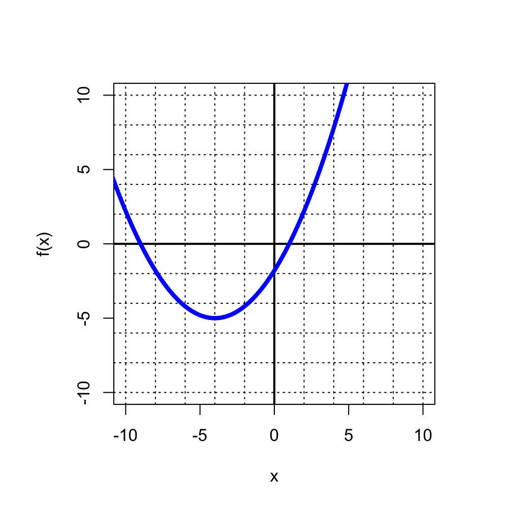

- What is the interval(s) over which the function is positive?
- What is the interval(s) over which the function is negative?
- What is the interval(s) over which the function is increasing?
- What is the interval(s) over which the function is decreasing?
- What is the domain (in interval notation)?
- What is the range (in interval notation)?
- Positive: (-∞,-9)U(1,∞)
- Negative: (-9,1)
- Increasing: (-4,∞)
- Decreasing: (-∞,-4)
- Domain: (-∞,∞)
- Range: [-5,∞)
- The function "is positive" when $f(x)>0$. The interval refers to the $x$ values (inputs) that produce a positive output. Determine where the curve is above the $x$ axis. Indicate "where" with the $x$ values at the endpoints: (-∞,-9)U(1,∞)
- The function "is negative" when $f(x)<0$. The interval refers to the $x$ values (inputs) that produce a negative output. Determine where the curve is below the $x$ axis. Indicate "where" with the $x$ values at the endpoints: (-9,1)
- The function is increasing when an ant going left-to-right is walking up hill: (-4,∞)
- The function is decreasing when an ant going left-to-right is walking down hill: (-∞,-4)

Consider the quadratic function graphed below:

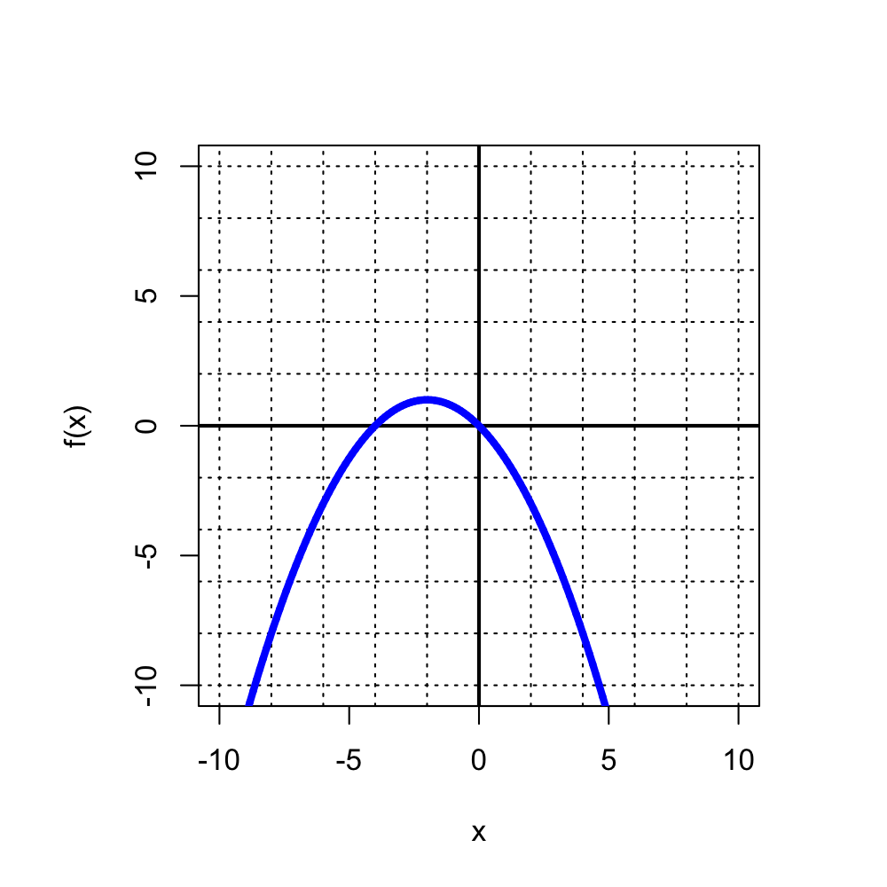

- What is the interval(s) over which the function is positive?
- What is the interval(s) over which the function is negative?
- What is the interval(s) over which the function is increasing?
- What is the interval(s) over which the function is decreasing?
- What is the domain (in interval notation)?
- What is the range (in interval notation)?
- Positive: (-4,0)
- Negative: (-∞,-4)U(0,∞)
- Increasing: (-∞,-2)
- Decreasing: (-2,∞)
- Domain: (-∞,∞)
- Range: (-∞,1]
- The function "is positive" when $f(x)>0$. The interval refers to the $x$ values (inputs) that produce a positive output. Determine where the curve is above the $x$ axis. Indicate "where" with the $x$ values at the endpoints: (-4,0)
- The function "is negative" when $f(x)<0$. The interval refers to the $x$ values (inputs) that produce a negative output. Determine where the curve is below the $x$ axis. Indicate "where" with the $x$ values at the endpoints: (-∞,-4)U(0,∞)
- The function is increasing when an ant going left-to-right is walking up hill: (-∞,-2)
- The function is decreasing when an ant going left-to-right is walking down hill: (-2,∞)

Consider the quadratic function graphed below:

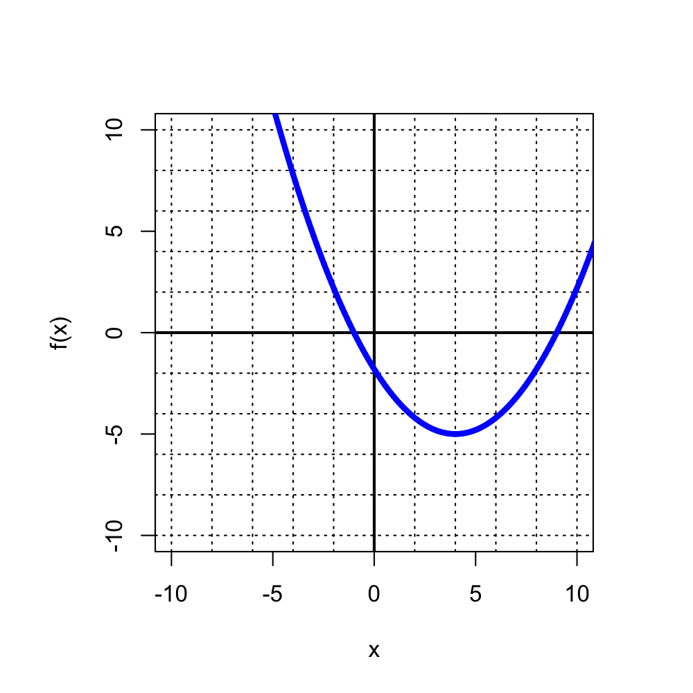

- What is the interval(s) over which the function is positive?
- What is the interval(s) over which the function is negative?
- What is the interval(s) over which the function is increasing?
- What is the interval(s) over which the function is decreasing?
- What is the domain (in interval notation)?
- What is the range (in interval notation)?
- Positive: (-∞,-1)U(9,∞)
- Negative: (-1,9)
- Increasing: (4,∞)
- Decreasing: (-∞,4)
- Domain: (-∞,∞)
- Range: [-5,∞)
- The function "is positive" when $f(x)>0$. The interval refers to the $x$ values (inputs) that produce a positive output. Determine where the curve is above the $x$ axis. Indicate "where" with the $x$ values at the endpoints: (-∞,-1)U(9,∞)
- The function "is negative" when $f(x)<0$. The interval refers to the $x$ values (inputs) that produce a negative output. Determine where the curve is below the $x$ axis. Indicate "where" with the $x$ values at the endpoints: (-1,9)
- The function is increasing when an ant going left-to-right is walking up hill: (4,∞)
- The function is decreasing when an ant going left-to-right is walking down hill: (-∞,4)

Consider the quadratic function graphed below:

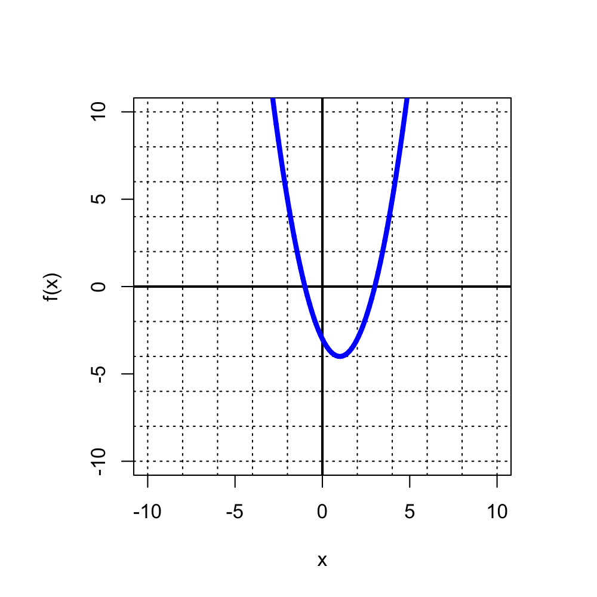

- What is the interval(s) over which the function is positive?
- What is the interval(s) over which the function is negative?
- What is the interval(s) over which the function is increasing?
- What is the interval(s) over which the function is decreasing?
- What is the domain (in interval notation)?
- What is the range (in interval notation)?
- Positive: (-∞,-1)U(3,∞)
- Negative: (-1,3)
- Increasing: (1,∞)
- Decreasing: (-∞,1)
- Domain: (-∞,∞)
- Range: [-4,∞)
- The function "is positive" when $f(x)>0$. The interval refers to the $x$ values (inputs) that produce a positive output. Determine where the curve is above the $x$ axis. Indicate "where" with the $x$ values at the endpoints: (-∞,-1)U(3,∞)
- The function "is negative" when $f(x)<0$. The interval refers to the $x$ values (inputs) that produce a negative output. Determine where the curve is below the $x$ axis. Indicate "where" with the $x$ values at the endpoints: (-1,3)
- The function is increasing when an ant going left-to-right is walking up hill: (1,∞)
- The function is decreasing when an ant going left-to-right is walking down hill: (-∞,1)

Consider the quadratic function graphed below:

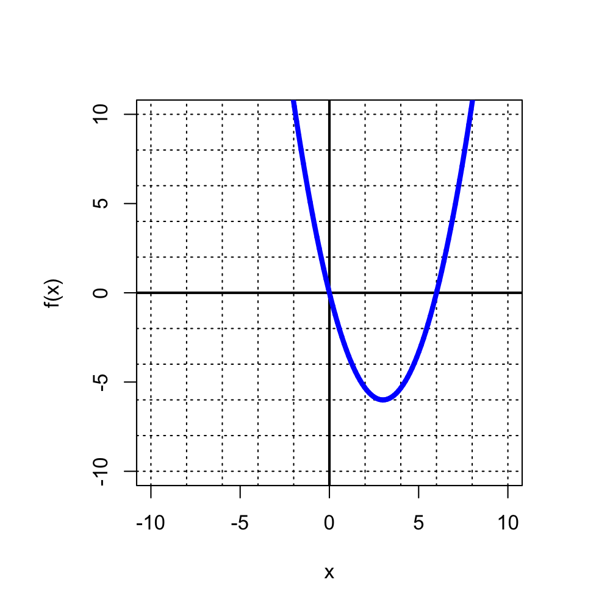

- What is the interval(s) over which the function is positive?
- What is the interval(s) over which the function is negative?
- What is the interval(s) over which the function is increasing?
- What is the interval(s) over which the function is decreasing?
- What is the domain (in interval notation)?
- What is the range (in interval notation)?
- Positive: (-∞,0)U(6,∞)
- Negative: (0,6)
- Increasing: (3,∞)
- Decreasing: (-∞,3)
- Domain: (-∞,∞)
- Range: [-6,∞)
- The function "is positive" when $f(x)>0$. The interval refers to the $x$ values (inputs) that produce a positive output. Determine where the curve is above the $x$ axis. Indicate "where" with the $x$ values at the endpoints: (-∞,0)U(6,∞)
- The function "is negative" when $f(x)<0$. The interval refers to the $x$ values (inputs) that produce a negative output. Determine where the curve is below the $x$ axis. Indicate "where" with the $x$ values at the endpoints: (0,6)
- The function is increasing when an ant going left-to-right is walking up hill: (3,∞)
- The function is decreasing when an ant going left-to-right is walking down hill: (-∞,3)

Consider the quadratic function graphed below:

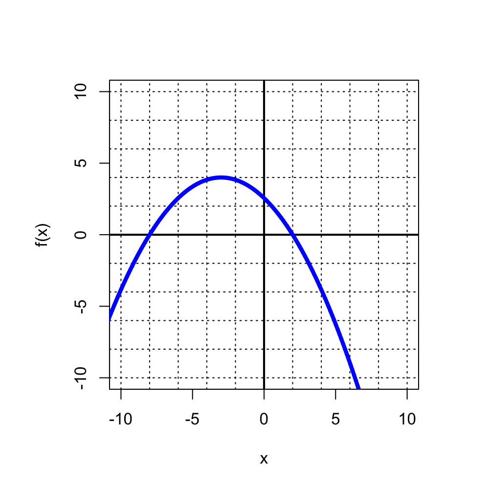

- What is the interval(s) over which the function is positive?
- What is the interval(s) over which the function is negative?
- What is the interval(s) over which the function is increasing?
- What is the interval(s) over which the function is decreasing?
- What is the domain (in interval notation)?
- What is the range (in interval notation)?
- Positive: (-8,2)
- Negative: (-∞,-8)U(2,∞)
- Increasing: (-∞,-3)
- Decreasing: (-3,∞)
- Domain: (-∞,∞)
- Range: (-∞,4]
- The function "is positive" when $f(x)>0$. The interval refers to the $x$ values (inputs) that produce a positive output. Determine where the curve is above the $x$ axis. Indicate "where" with the $x$ values at the endpoints: (-8,2)
- The function "is negative" when $f(x)<0$. The interval refers to the $x$ values (inputs) that produce a negative output. Determine where the curve is below the $x$ axis. Indicate "where" with the $x$ values at the endpoints: (-∞,-8)U(2,∞)
- The function is increasing when an ant going left-to-right is walking up hill: (-∞,-3)
- The function is decreasing when an ant going left-to-right is walking down hill: (-3,∞)

Consider the quadratic **equation** with a standard-form quadratic expression on the left side and zero on the right side.

$$x^{2}+{5}x-{6}~=~0$$

Find all solutions.

$x=-12$$x=-11$$x=-10$$x=-9$$x=-8$$x=-7$$x=-6$$x=-5$$x=-4$$x=-3$$x=-2$$x=-1$$x=0$$x=1$$x=2$$x=3$$x=4$$x=5$$x=6$$x=7$$x=8$$x=9$$x=10$$x=11$$x=12$

[Factor the left-side expression](https://chadworley.github.io/algtwo2026/u03/1031/outhtml/factor_quadratic.html).

$$(x+{6}) (x-{1})=0$$

The [zero-product property](https://en.wikipedia.org/wiki/Zero-product_property) tells us that if a product equals 0, then at least one of the factors of the product equals 0. In this case, we know the product of $(x+{6})$ and $(x-{1})$ equals zero. This means to satisfy the equation either $x+{6}$ equals zero or $x-{1}$ equals zero. Solve each of these using addition or subtraction.

- First solution:
  $$x+{6}=0$$
  $$x=-6$$
- Second solution:
  $$x-{1}=0$$
  $$x=1$$

Thus, the two solutions are $x=-6$ and $x=1$.

Consider the quadratic **equation** with a standard-form quadratic expression on the left side and zero on the right side.

$$x^{2}+{21}x+{110}~=~0$$

Find all solutions.

$x=-12$$x=-11$$x=-10$$x=-9$$x=-8$$x=-7$$x=-6$$x=-5$$x=-4$$x=-3$$x=-2$$x=-1$$x=0$$x=1$$x=2$$x=3$$x=4$$x=5$$x=6$$x=7$$x=8$$x=9$$x=10$$x=11$$x=12$

[Factor the left-side expression](https://chadworley.github.io/algtwo2026/u03/1031/outhtml/factor_quadratic.html).

$$(x+{10}) (x+{11})=0$$

The [zero-product property](https://en.wikipedia.org/wiki/Zero-product_property) tells us that if a product equals 0, then at least one of the factors of the product equals 0. In this case, we know the product of $(x+{10})$ and $(x+{11})$ equals zero. This means to satisfy the equation either $x+{10}$ equals zero or $x+{11}$ equals zero. Solve each of these using addition or subtraction.

- First solution:
  $$x+{10}=0$$
  $$x=-10$$
- Second solution:
  $$x+{11}=0$$
  $$x=-11$$

Thus, the two solutions are $x=-10$ and $x=-11$.

Consider the quadratic **equation** with a standard-form quadratic expression on the left side and zero on the right side.

$$x^{2}+{5}x+{4}~=~0$$

Find all solutions.

$x=-12$$x=-11$$x=-10$$x=-9$$x=-8$$x=-7$$x=-6$$x=-5$$x=-4$$x=-3$$x=-2$$x=-1$$x=0$$x=1$$x=2$$x=3$$x=4$$x=5$$x=6$$x=7$$x=8$$x=9$$x=10$$x=11$$x=12$

[Factor the left-side expression](https://chadworley.github.io/algtwo2026/u03/1031/outhtml/factor_quadratic.html).

$$(x+{4}) (x+{1})=0$$

The [zero-product property](https://en.wikipedia.org/wiki/Zero-product_property) tells us that if a product equals 0, then at least one of the factors of the product equals 0. In this case, we know the product of $(x+{4})$ and $(x+{1})$ equals zero. This means to satisfy the equation either $x+{4}$ equals zero or $x+{1}$ equals zero. Solve each of these using addition or subtraction.

- First solution:
  $$x+{4}=0$$
  $$x=-4$$
- Second solution:
  $$x+{1}=0$$
  $$x=-1$$

Thus, the two solutions are $x=-4$ and $x=-1$.

Consider the quadratic **equation** with a standard-form quadratic expression on the left side and zero on the right side.

$$x^{2}+{8}x+{7}~=~0$$

Find all solutions.

$x=-12$$x=-11$$x=-10$$x=-9$$x=-8$$x=-7$$x=-6$$x=-5$$x=-4$$x=-3$$x=-2$$x=-1$$x=0$$x=1$$x=2$$x=3$$x=4$$x=5$$x=6$$x=7$$x=8$$x=9$$x=10$$x=11$$x=12$

[Factor the left-side expression](https://chadworley.github.io/algtwo2026/u03/1031/outhtml/factor_quadratic.html).

$$(x+{1}) (x+{7})=0$$

The [zero-product property](https://en.wikipedia.org/wiki/Zero-product_property) tells us that if a product equals 0, then at least one of the factors of the product equals 0. In this case, we know the product of $(x+{1})$ and $(x+{7})$ equals zero. This means to satisfy the equation either $x+{1}$ equals zero or $x+{7}$ equals zero. Solve each of these using addition or subtraction.

- First solution:
  $$x+{1}=0$$
  $$x=-1$$
- Second solution:
  $$x+{7}=0$$
  $$x=-7$$

Thus, the two solutions are $x=-1$ and $x=-7$.

Consider the quadratic **equation** with a standard-form quadratic expression on the left side and zero on the right side.

$$x^{2}+{12}x+{11}~=~0$$

Find all solutions.

$x=-12$$x=-11$$x=-10$$x=-9$$x=-8$$x=-7$$x=-6$$x=-5$$x=-4$$x=-3$$x=-2$$x=-1$$x=0$$x=1$$x=2$$x=3$$x=4$$x=5$$x=6$$x=7$$x=8$$x=9$$x=10$$x=11$$x=12$

[Factor the left-side expression](https://chadworley.github.io/algtwo2026/u03/1031/outhtml/factor_quadratic.html).

$$(x+{11}) (x+{1})=0$$

The [zero-product property](https://en.wikipedia.org/wiki/Zero-product_property) tells us that if a product equals 0, then at least one of the factors of the product equals 0. In this case, we know the product of $(x+{11})$ and $(x+{1})$ equals zero. This means to satisfy the equation either $x+{11}$ equals zero or $x+{1}$ equals zero. Solve each of these using addition or subtraction.

- First solution:
  $$x+{11}=0$$
  $$x=-11$$
- Second solution:
  $$x+{1}=0$$
  $$x=-1$$

Thus, the two solutions are $x=-11$ and $x=-1$.

Consider the quadratic **equation** with a standard-form quadratic expression on the left side and zero on the right side.

$$x^{2}-{36}~=~0$$

Find all solutions.

$x=-12$$x=-11$$x=-10$$x=-9$$x=-8$$x=-7$$x=-6$$x=-5$$x=-4$$x=-3$$x=-2$$x=-1$$x=0$$x=1$$x=2$$x=3$$x=4$$x=5$$x=6$$x=7$$x=8$$x=9$$x=10$$x=11$$x=12$

[Factor the left-side expression](https://chadworley.github.io/algtwo2026/u03/1031/outhtml/factor_quadratic.html).

$$(x-{6}) (x+{6})=0$$

The [zero-product property](https://en.wikipedia.org/wiki/Zero-product_property) tells us that if a product equals 0, then at least one of the factors of the product equals 0. In this case, we know the product of $(x-{6})$ and $(x+{6})$ equals zero. This means to satisfy the equation either $x-{6}$ equals zero or $x+{6}$ equals zero. Solve each of these using addition or subtraction.

- First solution:
  $$x-{6}=0$$
  $$x=6$$
- Second solution:
  $$x+{6}=0$$
  $$x=-6$$

Thus, the two solutions are $x=6$ and $x=-6$.

Consider the quadratic **equation** with a standard-form quadratic expression on the left side and zero on the right side.

$$x^{2}+{3}x+{2}~=~0$$

Find all solutions.

$x=-12$$x=-11$$x=-10$$x=-9$$x=-8$$x=-7$$x=-6$$x=-5$$x=-4$$x=-3$$x=-2$$x=-1$$x=0$$x=1$$x=2$$x=3$$x=4$$x=5$$x=6$$x=7$$x=8$$x=9$$x=10$$x=11$$x=12$

[Factor the left-side expression](https://chadworley.github.io/algtwo2026/u03/1031/outhtml/factor_quadratic.html).

$$(x+{2}) (x+{1})=0$$

The [zero-product property](https://en.wikipedia.org/wiki/Zero-product_property) tells us that if a product equals 0, then at least one of the factors of the product equals 0. In this case, we know the product of $(x+{2})$ and $(x+{1})$ equals zero. This means to satisfy the equation either $x+{2}$ equals zero or $x+{1}$ equals zero. Solve each of these using addition or subtraction.

- First solution:
  $$x+{2}=0$$
  $$x=-2$$
- Second solution:
  $$x+{1}=0$$
  $$x=-1$$

Thus, the two solutions are $x=-2$ and $x=-1$.

Consider the quadratic **equation** with a standard-form quadratic expression on the left side and zero on the right side.

$$x^{2}-{64}~=~0$$

Find all solutions.

$x=-12$$x=-11$$x=-10$$x=-9$$x=-8$$x=-7$$x=-6$$x=-5$$x=-4$$x=-3$$x=-2$$x=-1$$x=0$$x=1$$x=2$$x=3$$x=4$$x=5$$x=6$$x=7$$x=8$$x=9$$x=10$$x=11$$x=12$

[Factor the left-side expression](https://chadworley.github.io/algtwo2026/u03/1031/outhtml/factor_quadratic.html).

$$(x-{8}) (x+{8})=0$$

The [zero-product property](https://en.wikipedia.org/wiki/Zero-product_property) tells us that if a product equals 0, then at least one of the factors of the product equals 0. In this case, we know the product of $(x-{8})$ and $(x+{8})$ equals zero. This means to satisfy the equation either $x-{8}$ equals zero or $x+{8}$ equals zero. Solve each of these using addition or subtraction.

- First solution:
  $$x-{8}=0$$
  $$x=8$$
- Second solution:
  $$x+{8}=0$$
  $$x=-8$$

Thus, the two solutions are $x=8$ and $x=-8$.

If we start with a generic quadratic equation and use [completing the square](https://en.wikipedia.org/wiki/Completing_the_square) to solve it, we can derive the [quadratic formula](https://en.wikipedia.org/wiki/Quadratic_formula):

- If $ax^2+bx+c=0$, then
  $$x~=~\frac{-b \pm
  \sqrt{b^2-4ac}}{2a}$$

Use the quadratic formula to find both solutions (rounded to the nearest hundredth) to the equation below.

$$-5x^2-11x+10~=~0$$

- $x=$
- or
- $x=$

Identify the parameters.

- The quadratic coefficient: $a=-5$
- The linear coefficient: $b=-11$
- The constant: $c=10$

Plug the numbers into the quadratic formula.

$$x~=~\frac{-(-11)\pm
\sqrt{(-11)^2-4(-5)(10)}}{2(-5)}$$

Simplify.

$$x~=~\frac{11\pm \sqrt{121
+200}}{-10}$$

Simplify MORE.

$$x~=~\frac{11\pm
\sqrt{321}}{-10}$$

Now, plug both expressions into a calculator.

$$x~=~\frac{11-
\sqrt{321}}{-10}~=~0.6916473 ~\approx 0.69$$

OR

$$x~=~\frac{11+
\sqrt{321}}{-10}~=~-2.8916473 ~\approx -2.89$$

If you are using a basic (one-line) scientific calculator, you can type the expressions like:

`(11-sqrt(321))/(-10)`

`(11+sqrt(321))/(-10)`

Or maybe...

`(11-√(321))/(-10)`

`(11+√(321))/(-10)`

If we start with a generic quadratic equation and use [completing the square](https://en.wikipedia.org/wiki/Completing_the_square) to solve it, we can derive the [quadratic formula](https://en.wikipedia.org/wiki/Quadratic_formula):

- If $ax^2+bx+c=0$, then
  $$x~=~\frac{-b \pm
  \sqrt{b^2-4ac}}{2a}$$

Use the quadratic formula to find both solutions (rounded to the nearest hundredth) to the equation below.

$$9x^2-11x-3~=~0$$

- $x=$
- or
- $x=$

Identify the parameters.

- The quadratic coefficient: $a=9$
- The linear coefficient: $b=-11$
- The constant: $c=-3$

Plug the numbers into the quadratic formula.

$$x~=~\frac{-(-11)\pm
\sqrt{(-11)^2-4(9)(-3)}}{2(9)}$$

Simplify.

$$x~=~\frac{11\pm \sqrt{121
+108}}{18}$$

Simplify MORE.

$$x~=~\frac{11\pm
\sqrt{229}}{18}$$

Now, plug both expressions into a calculator.

$$x~=~\frac{11-
\sqrt{229}}{18}~=~-0.229597 ~\approx -0.23$$

OR

$$x~=~\frac{11+
\sqrt{229}}{18}~=~1.4518192 ~\approx 1.45$$

If you are using a basic (one-line) scientific calculator, you can type the expressions like:

`(11-sqrt(229))/(18)`

`(11+sqrt(229))/(18)`

Or maybe...

`(11-√(229))/(18)`

`(11+√(229))/(18)`

If we start with a generic quadratic equation and use [completing the square](https://en.wikipedia.org/wiki/Completing_the_square) to solve it, we can derive the [quadratic formula](https://en.wikipedia.org/wiki/Quadratic_formula):

- If $ax^2+bx+c=0$, then
  $$x~=~\frac{-b \pm
  \sqrt{b^2-4ac}}{2a}$$

Use the quadratic formula to find both solutions (rounded to the nearest hundredth) to the equation below.

$$9x^2+10x-8~=~0$$

- $x=$
- or
- $x=$

Identify the parameters.

- The quadratic coefficient: $a=9$
- The linear coefficient: $b=10$
- The constant: $c=-8$

Plug the numbers into the quadratic formula.

$$x~=~\frac{-(10)\pm
\sqrt{(10)^2-4(9)(-8)}}{2(9)}$$

Simplify.

$$x~=~\frac{-10\pm \sqrt{100
+288}}{18}$$

Simplify MORE.

$$x~=~\frac{-10\pm
\sqrt{388}}{18}$$

Now, plug both expressions into a calculator.

$$x~=~\frac{-10-
\sqrt{388}}{18}~=~-1.6498731 ~\approx -1.65$$

OR

$$x~=~\frac{-10+
\sqrt{388}}{18}~=~0.538762 ~\approx 0.54$$

If you are using a basic (one-line) scientific calculator, you can type the expressions like:

`(-10-sqrt(388))/(18)`

`(-10+sqrt(388))/(18)`

Or maybe...

`(-10-√(388))/(18)`

`(-10+√(388))/(18)`

If we start with a generic quadratic equation and use [completing the square](https://en.wikipedia.org/wiki/Completing_the_square) to solve it, we can derive the [quadratic formula](https://en.wikipedia.org/wiki/Quadratic_formula):

- If $ax^2+bx+c=0$, then
  $$x~=~\frac{-b \pm
  \sqrt{b^2-4ac}}{2a}$$

Use the quadratic formula to find both solutions (rounded to the nearest hundredth) to the equation below.

$$9x^2-12x-3~=~0$$

- $x=$
- or
- $x=$

Identify the parameters.

- The quadratic coefficient: $a=9$
- The linear coefficient: $b=-12$
- The constant: $c=-3$

Plug the numbers into the quadratic formula.

$$x~=~\frac{-(-12)\pm
\sqrt{(-12)^2-4(9)(-3)}}{2(9)}$$

Simplify.

$$x~=~\frac{12\pm \sqrt{144
+108}}{18}$$

Simplify MORE.

$$x~=~\frac{12\pm
\sqrt{252}}{18}$$

Now, plug both expressions into a calculator.

$$x~=~\frac{12-
\sqrt{252}}{18}~=~-0.2152504 ~\approx -0.22$$

OR

$$x~=~\frac{12+
\sqrt{252}}{18}~=~1.5485838 ~\approx 1.55$$

If you are using a basic (one-line) scientific calculator, you can type the expressions like:

`(12-sqrt(252))/(18)`

`(12+sqrt(252))/(18)`

Or maybe...

`(12-√(252))/(18)`

`(12+√(252))/(18)`

If we start with a generic quadratic equation and use [completing the square](https://en.wikipedia.org/wiki/Completing_the_square) to solve it, we can derive the [quadratic formula](https://en.wikipedia.org/wiki/Quadratic_formula):

- If $ax^2+bx+c=0$, then
  $$x~=~\frac{-b \pm
  \sqrt{b^2-4ac}}{2a}$$

Use the quadratic formula to find both solutions (rounded to the nearest hundredth) to the equation below.

$$12x^2-6x-9~=~0$$

- $x=$
- or
- $x=$

Identify the parameters.

- The quadratic coefficient: $a=12$
- The linear coefficient: $b=-6$
- The constant: $c=-9$

Plug the numbers into the quadratic formula.

$$x~=~\frac{-(-6)\pm
\sqrt{(-6)^2-4(12)(-9)}}{2(12)}$$

Simplify.

$$x~=~\frac{6\pm \sqrt{36
+432}}{24}$$

Simplify MORE.

$$x~=~\frac{6\pm
\sqrt{468}}{24}$$

Now, plug both expressions into a calculator.

$$x~=~\frac{6-
\sqrt{468}}{24}~=~-0.6513878 ~\approx -0.65$$

OR

$$x~=~\frac{6+ \sqrt{468}}{24}~=~1.1513878
~\approx 1.15$$

If you are using a basic (one-line) scientific calculator, you can type the expressions like:

`(6-sqrt(468))/(24)`

`(6+sqrt(468))/(24)`

Or maybe...

`(6-√(468))/(24)`

`(6+√(468))/(24)`

If we start with a generic quadratic equation and use [completing the square](https://en.wikipedia.org/wiki/Completing_the_square) to solve it, we can derive the [quadratic formula](https://en.wikipedia.org/wiki/Quadratic_formula):

- If $ax^2+bx+c=0$, then
  $$x~=~\frac{-b \pm
  \sqrt{b^2-4ac}}{2a}$$

Use the quadratic formula to find both solutions (rounded to the nearest hundredth) to the equation below.

$$-6x^2-12x+3~=~0$$

- $x=$
- or
- $x=$

Identify the parameters.

- The quadratic coefficient: $a=-6$
- The linear coefficient: $b=-12$
- The constant: $c=3$

Plug the numbers into the quadratic formula.

$$x~=~\frac{-(-12)\pm
\sqrt{(-12)^2-4(-6)(3)}}{2(-6)}$$

Simplify.

$$x~=~\frac{12\pm \sqrt{144
+72}}{-12}$$

Simplify MORE.

$$x~=~\frac{12\pm
\sqrt{216}}{-12}$$

Now, plug both expressions into a calculator.

$$x~=~\frac{12-
\sqrt{216}}{-12}~=~0.2247449 ~\approx 0.22$$

OR

$$x~=~\frac{12+
\sqrt{216}}{-12}~=~-2.2247449 ~\approx -2.22$$

If you are using a basic (one-line) scientific calculator, you can type the expressions like:

`(12-sqrt(216))/(-12)`

`(12+sqrt(216))/(-12)`

Or maybe...

`(12-√(216))/(-12)`

`(12+√(216))/(-12)`

If we start with a generic quadratic equation and use [completing the square](https://en.wikipedia.org/wiki/Completing_the_square) to solve it, we can derive the [quadratic formula](https://en.wikipedia.org/wiki/Quadratic_formula):

- If $ax^2+bx+c=0$, then
  $$x~=~\frac{-b \pm
  \sqrt{b^2-4ac}}{2a}$$

Use the quadratic formula to find both solutions (rounded to the nearest hundredth) to the equation below.

$$3x^2-7x-10~=~0$$

- $x=$
- or
- $x=$

Identify the parameters.

- The quadratic coefficient: $a=3$
- The linear coefficient: $b=-7$
- The constant: $c=-10$

Plug the numbers into the quadratic formula.

$$x~=~\frac{-(-7)\pm
\sqrt{(-7)^2-4(3)(-10)}}{2(3)}$$

Simplify.

$$x~=~\frac{7\pm \sqrt{49
+120}}{6}$$

Simplify MORE.

$$x~=~\frac{7\pm
\sqrt{169}}{6}$$

Now, plug both expressions into a calculator.

$$x~=~\frac{7- \sqrt{169}}{6}~=~-1
~\approx -1$$

OR

$$x~=~\frac{7+ \sqrt{169}}{6}~=~3.3333333
~\approx 3.33$$

If you are using a basic (one-line) scientific calculator, you can type the expressions like:

`(7-sqrt(169))/(6)`

`(7+sqrt(169))/(6)`

Or maybe...

`(7-√(169))/(6)`

`(7+√(169))/(6)`

If we start with a generic quadratic equation and use [completing the square](https://en.wikipedia.org/wiki/Completing_the_square) to solve it, we can derive the [quadratic formula](https://en.wikipedia.org/wiki/Quadratic_formula):

- If $ax^2+bx+c=0$, then
  $$x~=~\frac{-b \pm
  \sqrt{b^2-4ac}}{2a}$$

Use the quadratic formula to find both solutions (rounded to the nearest hundredth) to the equation below.

$$-11x^2+10x+8~=~0$$

- $x=$
- or
- $x=$

Identify the parameters.

- The quadratic coefficient: $a=-11$
- The linear coefficient: $b=10$
- The constant: $c=8$

Plug the numbers into the quadratic formula.

$$x~=~\frac{-(10)\pm
\sqrt{(10)^2-4(-11)(8)}}{2(-11)}$$

Simplify.

$$x~=~\frac{-10\pm \sqrt{100
+352}}{-22}$$

Simplify MORE.

$$x~=~\frac{-10\pm
\sqrt{452}}{-22}$$

Now, plug both expressions into a calculator.

$$x~=~\frac{-10-
\sqrt{452}}{-22}~=~1.4209223 ~\approx 1.42$$

OR

$$x~=~\frac{-10+
\sqrt{452}}{-22}~=~-0.5118314 ~\approx -0.51$$

If you are using a basic (one-line) scientific calculator, you can type the expressions like:

`(-10-sqrt(452))/(-22)`

`(-10+sqrt(452))/(-22)`

Or maybe...

`(-10-√(452))/(-22)`

`(-10+√(452))/(-22)`

On an alien planet, the acceleration due to gravity is -13.8 $\mathrm{m/s^2}$. At $t=0$, a projectile is launched straight up with a speed of 32 $\mathrm{m/s}$. The effect of air resistance is minimal, so the projectile's height, $p$, is a quadratic function of time.

$$p(t)~=~-6.9t^2+32t$$

After $t=0.3$ seconds, a balloon is released from the same location as the projectile was launched. The balloon rises at a constant speed of 8.8 $\mathrm{m/s}$, thus the balloon's height, $b$, is a linear function of time.

$$b(t)~=~8.8\cdot(t-0.3)$$

[figure not shown]

At what time (in seconds after the projectile is launched) does the balloon get popped by the projectile?

To find the intersection of $y=p(t)$ and $y=b(t)$, we find $t$ such that $p(t)=b(t)$ and $t>0$.

$$\begin{align*}
p(t) ~&=~ b(t)\\
-6.9t^2+32t ~&=~ 8.8\cdot(t-0.3)
\end{align*}$$

Distribute the right-hand side of the equation.

$$-6.9t^2+32t ~=~ 8.8t-2.64$$

Use addition (or subtraction) to bring all terms to the right-hand side.

$$0 ~=~ 6.9t^2-32t +
8.8t-2.64$$

Combine like terms.

$$0 ~=~ 6.9t^2-23.2t-2.64$$

Use the quadratic formula.

$$t = \frac{23.2 \pm
\sqrt{(-23.2)^2-4(6.9)(-2.64)}}{2\cdot(6.9)}$$

Our two possible times are $t=-0.1101824$ and $t=3.4725013$. We are only interested in the positive solution.

$$t ~=~ 3.473\, \mathrm{s}$$

On an alien planet, the acceleration due to gravity is -7 $\mathrm{m/s^2}$. At $t=0$, a projectile is launched straight up with a speed of 20.9 $\mathrm{m/s}$. The effect of air resistance is minimal, so the projectile's height, $p$, is a quadratic function of time.

$$p(t)~=~-3.5t^2+20.9t$$

After $t=1.6$ seconds, a balloon is released from the same location as the projectile was launched. The balloon rises at a constant speed of 9.9 $\mathrm{m/s}$, thus the balloon's height, $b$, is a linear function of time.

$$b(t)~=~9.9\cdot(t-1.6)$$

[figure not shown]

At what time (in seconds after the projectile is launched) does the balloon get popped by the projectile?

To find the intersection of $y=p(t)$ and $y=b(t)$, we find $t$ such that $p(t)=b(t)$ and $t>0$.

$$\begin{align*}
p(t) ~&=~ b(t)\\
-3.5t^2+20.9t ~&=~ 9.9\cdot(t-1.6)
\end{align*}$$

Distribute the right-hand side of the equation.

$$-3.5t^2+20.9t ~=~
9.9t-15.84$$

Use addition (or subtraction) to bring all terms to the right-hand side.

$$0 ~=~ 3.5t^2-20.9t +
9.9t-15.84$$

Combine like terms.

$$0 ~=~ 3.5t^2-11t-15.84$$

Use the quadratic formula.

$$t = \frac{11 \pm
\sqrt{(-11)^2-4(3.5)(-15.84)}}{2\cdot(3.5)}$$

Our two possible times are $t=-1.073397$ and $t=4.2162541$. We are only interested in the positive solution.

$$t ~=~ 4.216\, \mathrm{s}$$

On an alien planet, the acceleration due to gravity is -18.2 $\mathrm{m/s^2}$. At $t=0$, a projectile is launched straight up with a speed of 42 $\mathrm{m/s}$. The effect of air resistance is minimal, so the projectile's height, $p$, is a quadratic function of time.

$$p(t)~=~-9.1t^2+42t$$

After $t=1.2$ seconds, a balloon is released from the same location as the projectile was launched. The balloon rises at a constant speed of 7.1 $\mathrm{m/s}$, thus the balloon's height, $b$, is a linear function of time.

$$b(t)~=~7.1\cdot(t-1.2)$$

[figure not shown]

At what time (in seconds after the projectile is launched) does the balloon get popped by the projectile?

To find the intersection of $y=p(t)$ and $y=b(t)$, we find $t$ such that $p(t)=b(t)$ and $t>0$.

$$\begin{align*}
p(t) ~&=~ b(t)\\
-9.1t^2+42t ~&=~ 7.1\cdot(t-1.2)
\end{align*}$$

Distribute the right-hand side of the equation.

$$-9.1t^2+42t ~=~ 7.1t-8.52$$

Use addition (or subtraction) to bring all terms to the right-hand side.

$$0 ~=~ 9.1t^2-42t +
7.1t-8.52$$

Combine like terms.

$$0 ~=~ 9.1t^2-34.9t-8.52$$

Use the quadratic formula.

$$t = \frac{34.9 \pm
\sqrt{(-34.9)^2-4(9.1)(-8.52)}}{2\cdot(9.1)}$$

Our two possible times are $t=-0.230297$ and $t=4.0654619$. We are only interested in the positive solution.

$$t ~=~ 4.065\, \mathrm{s}$$

On an alien planet, the acceleration due to gravity is -12.6 $\mathrm{m/s^2}$. At $t=0$, a projectile is launched straight up with a speed of 52.8 $\mathrm{m/s}$. The effect of air resistance is minimal, so the projectile's height, $p$, is a quadratic function of time.

$$p(t)~=~-6.3t^2+52.8t$$

After $t=0.9$ seconds, a balloon is released from the same location as the projectile was launched. The balloon rises at a constant speed of 8.1 $\mathrm{m/s}$, thus the balloon's height, $b$, is a linear function of time.

$$b(t)~=~8.1\cdot(t-0.9)$$

[figure not shown]

At what time (in seconds after the projectile is launched) does the balloon get popped by the projectile?

To find the intersection of $y=p(t)$ and $y=b(t)$, we find $t$ such that $p(t)=b(t)$ and $t>0$.

$$\begin{align*}
p(t) ~&=~ b(t)\\
-6.3t^2+52.8t ~&=~ 8.1\cdot(t-0.9)
\end{align*}$$

Distribute the right-hand side of the equation.

$$-6.3t^2+52.8t ~=~ 8.1t-7.29$$

Use addition (or subtraction) to bring all terms to the right-hand side.

$$0 ~=~ 6.3t^2-52.8t +
8.1t-7.29$$

Combine like terms.

$$0 ~=~ 6.3t^2-44.7t-7.29$$

Use the quadratic formula.

$$t = \frac{44.7 \pm
\sqrt{(-44.7)^2-4(6.3)(-7.29)}}{2\cdot(6.3)}$$

Our two possible times are $t=-0.1595016$ and $t=7.2547397$. We are only interested in the positive solution.

$$t ~=~ 7.255\, \mathrm{s}$$

On an alien planet, the acceleration due to gravity is -13.8 $\mathrm{m/s^2}$. At $t=0$, a projectile is launched straight up with a speed of 37.3 $\mathrm{m/s}$. The effect of air resistance is minimal, so the projectile's height, $p$, is a quadratic function of time.

$$p(t)~=~-6.9t^2+37.3t$$

After $t=1.5$ seconds, a balloon is released from the same location as the projectile was launched. The balloon rises at a constant speed of 8.2 $\mathrm{m/s}$, thus the balloon's height, $b$, is a linear function of time.

$$b(t)~=~8.2\cdot(t-1.5)$$

[figure not shown]

At what time (in seconds after the projectile is launched) does the balloon get popped by the projectile?

To find the intersection of $y=p(t)$ and $y=b(t)$, we find $t$ such that $p(t)=b(t)$ and $t>0$.

$$\begin{align*}
p(t) ~&=~ b(t)\\
-6.9t^2+37.3t ~&=~ 8.2\cdot(t-1.5)
\end{align*}$$

Distribute the right-hand side of the equation.

$$-6.9t^2+37.3t ~=~ 8.2t-12.3$$

Use addition (or subtraction) to bring all terms to the right-hand side.

$$0 ~=~ 6.9t^2-37.3t +
8.2t-12.3$$

Combine like terms.

$$0 ~=~ 6.9t^2-29.1t-12.3$$

Use the quadratic formula.

$$t = \frac{29.1 \pm
\sqrt{(-29.1)^2-4(6.9)(-12.3)}}{2\cdot(6.9)}$$

Our two possible times are $t=-0.3871421$ and $t=4.6045334$. We are only interested in the positive solution.

$$t ~=~ 4.605\, \mathrm{s}$$

On an alien planet, the acceleration due to gravity is -11 $\mathrm{m/s^2}$. At $t=0$, a projectile is launched straight up with a speed of 40 $\mathrm{m/s}$. The effect of air resistance is minimal, so the projectile's height, $p$, is a quadratic function of time.

$$p(t)~=~-5.5t^2+40t$$

After $t=0.9$ seconds, a balloon is released from the same location as the projectile was launched. The balloon rises at a constant speed of 9.8 $\mathrm{m/s}$, thus the balloon's height, $b$, is a linear function of time.

$$b(t)~=~9.8\cdot(t-0.9)$$

[figure not shown]

At what time (in seconds after the projectile is launched) does the balloon get popped by the projectile?

To find the intersection of $y=p(t)$ and $y=b(t)$, we find $t$ such that $p(t)=b(t)$ and $t>0$.

$$\begin{align*}
p(t) ~&=~ b(t)\\
-5.5t^2+40t ~&=~ 9.8\cdot(t-0.9)
\end{align*}$$

Distribute the right-hand side of the equation.

$$-5.5t^2+40t ~=~ 9.8t-8.82$$

Use addition (or subtraction) to bring all terms to the right-hand side.

$$0 ~=~ 5.5t^2-40t +
9.8t-8.82$$

Combine like terms.

$$0 ~=~ 5.5t^2-30.2t-8.82$$

Use the quadratic formula.

$$t = \frac{30.2 \pm
\sqrt{(-30.2)^2-4(5.5)(-8.82)}}{2\cdot(5.5)}$$

Our two possible times are $t=-0.2779801$ and $t=5.7688892$. We are only interested in the positive solution.

$$t ~=~ 5.769\, \mathrm{s}$$

On an alien planet, the acceleration due to gravity is -16.4 $\mathrm{m/s^2}$. At $t=0$, a projectile is launched straight up with a speed of 50.9 $\mathrm{m/s}$. The effect of air resistance is minimal, so the projectile's height, $p$, is a quadratic function of time.

$$p(t)~=~-8.2t^2+50.9t$$

After $t=0.4$ seconds, a balloon is released from the same location as the projectile was launched. The balloon rises at a constant speed of 7.4 $\mathrm{m/s}$, thus the balloon's height, $b$, is a linear function of time.

$$b(t)~=~7.4\cdot(t-0.4)$$

[figure not shown]

At what time (in seconds after the projectile is launched) does the balloon get popped by the projectile?

To find the intersection of $y=p(t)$ and $y=b(t)$, we find $t$ such that $p(t)=b(t)$ and $t>0$.

$$\begin{align*}
p(t) ~&=~ b(t)\\
-8.2t^2+50.9t ~&=~ 7.4\cdot(t-0.4)
\end{align*}$$

Distribute the right-hand side of the equation.

$$-8.2t^2+50.9t ~=~ 7.4t-2.96$$

Use addition (or subtraction) to bring all terms to the right-hand side.

$$0 ~=~ 8.2t^2-50.9t +
7.4t-2.96$$

Combine like terms.

$$0 ~=~ 8.2t^2-43.5t-2.96$$

Use the quadratic formula.

$$t = \frac{43.5 \pm
\sqrt{(-43.5)^2-4(8.2)(-2.96)}}{2\cdot(8.2)}$$

Our two possible times are $t=-0.0671948$ and $t=5.3720729$. We are only interested in the positive solution.

$$t ~=~ 5.372\, \mathrm{s}$$

On an alien planet, the acceleration due to gravity is -17.4 $\mathrm{m/s^2}$. At $t=0$, a projectile is launched straight up with a speed of 41.9 $\mathrm{m/s}$. The effect of air resistance is minimal, so the projectile's height, $p$, is a quadratic function of time.

$$p(t)~=~-8.7t^2+41.9t$$

After $t=0.4$ seconds, a balloon is released from the same location as the projectile was launched. The balloon rises at a constant speed of 9.2 $\mathrm{m/s}$, thus the balloon's height, $b$, is a linear function of time.

$$b(t)~=~9.2\cdot(t-0.4)$$

[figure not shown]

At what time (in seconds after the projectile is launched) does the balloon get popped by the projectile?

To find the intersection of $y=p(t)$ and $y=b(t)$, we find $t$ such that $p(t)=b(t)$ and $t>0$.

$$\begin{align*}
p(t) ~&=~ b(t)\\
-8.7t^2+41.9t ~&=~ 9.2\cdot(t-0.4)
\end{align*}$$

Distribute the right-hand side of the equation.

$$-8.7t^2+41.9t ~=~ 9.2t-3.68$$

Use addition (or subtraction) to bring all terms to the right-hand side.

$$0 ~=~ 8.7t^2-41.9t +
9.2t-3.68$$

Combine like terms.

$$0 ~=~ 8.7t^2-32.7t-3.68$$

Use the quadratic formula.

$$t = \frac{32.7 \pm
\sqrt{(-32.7)^2-4(8.7)(-3.68)}}{2\cdot(8.7)}$$

Our two possible times are $t=-0.1093565$ and $t=3.8679772$. We are only interested in the positive solution.

$$t ~=~ 3.868\, \mathrm{s}$$